# SElshahawy_Assign7

Salma Elshahawy

3/10/2020

## Question_1

Let X1, X2, . . . , Xn be n mutually independent random variables, each of which is uniformly distributed on the integers from 1 to k. Let Y denote the minimum of the Xi’s. Find the distribution of Y.

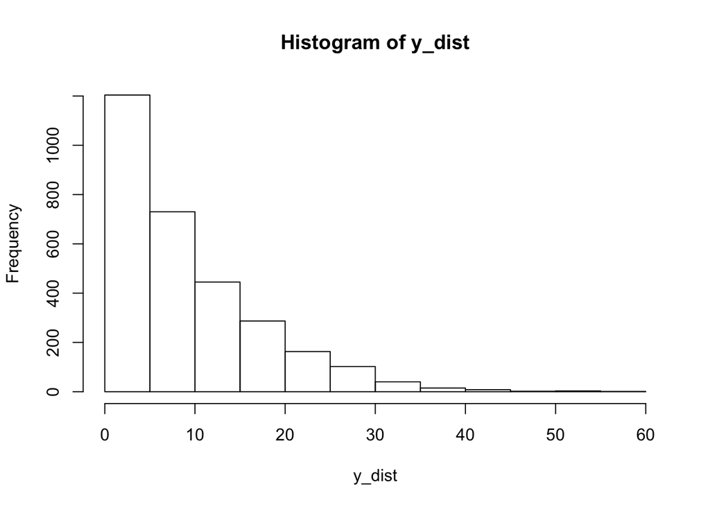

```r
set.seed(10000)
k = 100
n = 10
y_dist <- replicate(3000, {
  y_i = min(sample(1:k, n, replace=TRUE))
})

hist(y_dist)
```

## Question_2

Your organization owns a copier (future lawyers, etc.) or MRI (future doctors). This machine has a manufacturer’s expected lifetime of 10 years. This means that we expect one failure every ten years. (Include the probability statements and R Code for each part.).

### a.

What is the probability that the machine will fail after 8 years?. Provide also the expected value and standard deviation. Model as a geometric. (Hint: the probability is equivalent to not failing during the first 8 years..)

```r
p_success = 1/11
Exp_value = 1/p_success
Exp_value
```

```
## [1] 11
```

```r
Sd = Exp_value
Sd
```

```
## [1] 11
```

```r
pgeom(8,1/11)
```

```
## [1] 0.5759024
```

### b.

What is the probability that the machine will fail after 8 years?. Provide also the expected value and standard deviation. Model as an exponential.

$$E(x)=\frac { 1 }{ \lambda }$$
$$\lambda \quad =\quad \frac { 1 }{ 10 }$$

$$var(x)\quad =\quad \frac { 1 }{ { \lambda }^{ 2 } }$$
$$SD(x)\quad =\quad \frac { 1 }{ { \lambda } }$$
$$SD(x)\quad =\quad 10$$

```r
pexp(8,1/10)
```

```
## [1] 0.550671
```

### c.

What is the probability that the machine will fail after 8 years?. Provide also the expected value and standard deviation. Model as a binomial. (Hint: 0 success in 8 years)

$$E(x)=\frac { 1 }{ \lambda }$$

$$E(x)=10$$

$$np=10$$
$$q=(1 - p) = 0.5$$

$$n=\frac { 10 }{ 0.5 } = 20$$

$$SD(x)\quad =\quad \sqrt { np(1-p) } = \sqrt { 5}$$

```r
pbinom(8, size=20, prob=0.5)
```

```
## [1] 0.2517223
```

### d.

What is the probability that the machine will fail after 8 years?. Provide also the expected value and standard deviation. Model as a Poisson.

$$E(x)=10$$

$$\lambda =10$$
$$var(x)\quad =10$$
$$SD(x)\quad = \sqrt { 10}$$

```r
ppois(8, lambda=10, lower=TRUE) # lower tail
```

```
## [1] 0.3328197
```